# 城市绿地占比：顶端被削平，不是整体变绿

TidyTuesday · 2026-09-22 (Week 38)

作者

zlZayn

发布于

2026年10月28日

# 顶端被削平，而不是整体变绿

145 / 1,112 座城市在 2025 年还有记录（**13.0%**）；而这两端都有数的 145 座里，绿地占比超过 40% 的城市从 **11 座掉到 0 座**

这份库里「没有值」和「值为 0」是两件事，而且 2025 那一列有 **87%** 的行是空的。先把「谁真的被记了两次」这件事画清楚，再谈绿地是多还是少——否则任何一条「全球城市在变绿 / 变秃」的趋势线，都是把不同的城市串在同一根线上。

## 一、先看口径：2025 年只剩 145 座城市

> raw 5600 -> plotted 145 (40 行是区域汇总（每年 8 行，不是城市）; 967 座城市没有 2025 记录)

**40 行不是城市。** 每年 8 行是区域汇总（`cityCode`、`cityName`、`sdgSubRegion` 三列全空），其中一行叫 `Global Average`；它的 1990 年值是 14.9174，而 1,112 座城市当年的简单均值是 14.8955——差 0.02 个百分点，可见汇总行就是城市行的简单平均。把它留在表里跑排序，`Global Average` 会挤进「绿地占比最高的城市」名单。

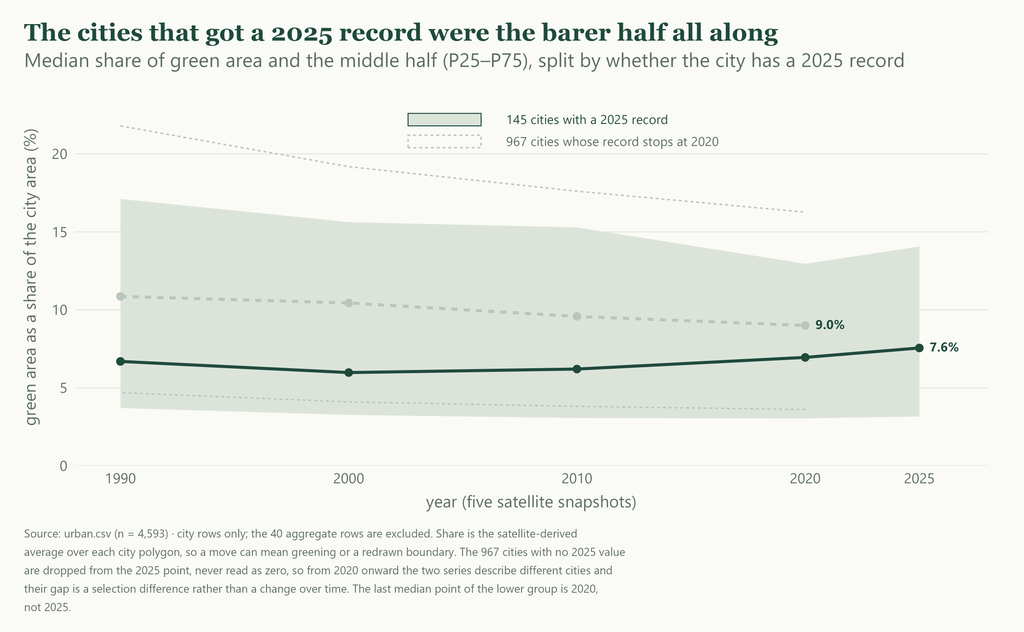

图 1: Two medians 4.2 points apart in 1990 and 2.1 points apart in 2020: the 145 cities that got a 2025 record were the barer half of the database from the start.

**读数**：两条中位线在靠近，但靠近的方式是**上面那条在掉**，不是下面那条追上来。967 座没有 2025 记录的城市，中位占比从 1990 年的 10.9% 一路降到 2020 年的 9.0%。跌了 1.9 个百分点。

有 2025 记录的那 145 座正相反，起点只有 6.7%。它先跌到 2000 年的 6.0%，之后回到 7.6%。

也就是「被记了两次的那批」在 2000 年之后是**往上走**的，而只被记到 2020 年的那批一路向下。但这张图不能证明任何一方在变绿。

表 1: 图 1 的原始数字（同一份聚合；2025 行缺失 = 该组在 2025 年没有记录，不是 0）

| 组 | 年份 | 城市数 | P25 % | 中位数 % | P75 % |
| --- | --- | --- | --- | --- | --- |
| 145 座（两端都有记录） | 1990 | 145 | 3.70 | 6.69 | 17.11 |
| 145 座（两端都有记录） | 2000 | 145 | 3.26 | 5.98 | 15.63 |
| 145 座（两端都有记录） | 2010 | 145 | 3.06 | 6.20 | 15.29 |
| 145 座（两端都有记录） | 2020 | 145 | 3.04 | 6.95 | 12.96 |
| 145 座（两端都有记录） | 2025 | 145 | 3.16 | 7.56 | 14.06 |
| 967 座（2025 无记录） | 1990 | 967 | 4.69 | 10.86 | 21.80 |
| 967 座（2025 无记录） | 2000 | 967 | 4.10 | 10.44 | 19.18 |
| 967 座（2025 无记录） | 2010 | 967 | 3.81 | 9.58 | 17.61 |
| 967 座（2025 无记录） | 2020 | 967 | 3.61 | 9.00 | 16.27 |

## 二、两端都有数的 145 座：占比在顶端被削平

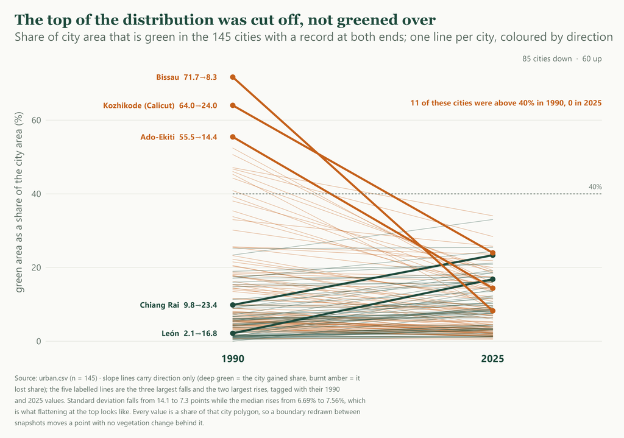

图 2: All eleven cities above 40% green in 1990 sit below 35% in 2025, while the median city moved the other way and gained 0.9 points.

**读数**：85 座跌、60 座涨，而中位数是**涨的**。它从 6.69% 升到 7.56%，均值却反向。

均值 12.5% → 9.1%。标准差也从 14.1 缩到 7.3。最大值从 71.7% 掉到 34.0%。

**掉的是顶端**：1990 年 40% 以上的 11 座城市，到 2025 年一座不剩。起点与变化量的相关系数是 -0.86，起点越高跌得越多——这是均值回归的形态，不是「所有城市都在失去绿地」。

跌得最狠的是 **Bissau**，71.7% → 8.3%（-63.4 个百分点）。涨得最多的是 **León**（尼加拉瓜），2.1% → 16.8%。

**不能推的结论**：这是 145 座城市（73 个国家）的构成变化，不是全球城市的面貌变化。

全库 1,112 座里 967 座根本没有第二次观测。而这 145 座本身就是「更秃的一半」——把它们的变化当成世界趋势，会系统性高估绿地流失。

表 2: 图 2 的原始数字（同一批 145 座城市；末三行是 2025 年占比最高的三座，用来看顶端被削到什么程度）

| 方向 | 城市 | 国家 | 区域 | 1990 % | 2025 % | 变化 pp |
| --- | --- | --- | --- | --- | --- | --- |
| 跌得最狠 | Bissau | Guinea-Bissau | Sub-Saharan Africa | 71.7 | 8.3 | -63.4 |
| 跌得最狠 | Ado-Ekiti | Nigeria | Sub-Saharan Africa | 55.5 | 14.4 | -41.1 |
| 跌得最狠 | Kozhikode (Calicut) | India | Central Asia and Southern Asia | 64.0 | 24.0 | -40.0 |
| 涨得最多 | León | Nicaragua | Latin America and the Caribbean | 2.1 | 16.8 | +14.7 |
| 涨得最多 | Chiang Rai | Thailand | Eastern Asia and South-eastern Asia | 9.8 | 23.4 | +13.5 |
| 2025 最高 | Blumenau | Brazil | Latin America and the Caribbean | 47.1 | 34.0 | -13.1 |
| 2025 最高 | Warszawa (Warsaw) | Poland | Northern America and Europe | 23.4 | 33.0 | +9.6 |
| 2025 最高 | Kendari | Indonesia | Eastern Asia and South-eastern Asia | 46.8 | 28.4 | -18.3 |

## 三、越挤的城市跌得越多，越铺开的反而涨

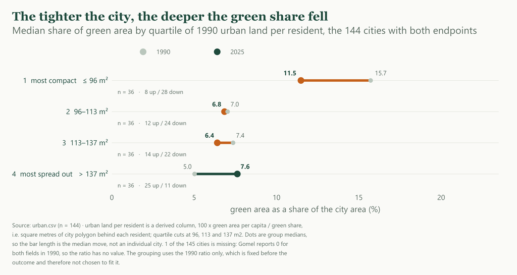

图 3: Cities packed into under 97 square metres of urban land per resident lost 4.2 points of green share; the most spread-out quartile gained 2.6.

**读数**：最紧凑的一档跌得最多，最铺开的一档反而涨。最紧凑的一档（每位居民背后的城市面积 ≤ 96 m²）中位占比从 15.72% 掉到 11.49%。

跌了 4.2 个百分点。36 座里只有 8 座变绿。

最铺开的一档（> 137 m²）反过来：从 5.03% 涨到 7.62%。36 座里反过来有 25 座变绿。

**中间两档几乎不动**：第二档 7.03% → 6.84%。第三档 7.37% → 6.41%。

这是第二节「顶端被削平」的另一面。挤得紧的城市 1990 年绿地占比本来就高（第一档中位 15.7%），起点高所以跌得多；铺开的城市起点低得多（5.0%），涨一点就显得可观。

每档只有 36 座，档内的中间一半跨度很宽：最紧凑档 1990 年从 6.0% 到 33.2%。所以这 4 组的中位数差异只能读成方向，不能读成效应大小。

表 3: 图 3 的原始数字（面积档按 1990 年的派生列四分位切分；P25 / P75 只在本表出现，图上不画，避免压盖）

| 规模档 | 城市数 | 1990 中位 % | 1990 P25 | 1990 P75 | 2025 中位 % | 2025 P25 | 2025 P75 | 变化 pp | 变绿 / 变秃 |
| --- | --- | --- | --- | --- | --- | --- | --- | --- | --- |
| 1 most compact ≤ 96 m² | 36 | 15.72 | 6.01 | 33.20 | 11.49 | 4.02 | 19.23 | -4.23 | 8 / 28 |
| 2 96–113 m² | 36 | 7.03 | 3.61 | 17.57 | 6.84 | 3.18 | 13.65 | -0.19 | 12 / 24 |
| 3 113–137 m² | 36 | 7.37 | 3.72 | 14.31 | 6.41 | 2.15 | 9.51 | -0.96 | 14 / 22 |
| 4 most spread out > 137 m² | 36 | 5.03 | 1.35 | 6.86 | 7.62 | 3.43 | 10.70 | +2.60 | 25 / 11 |

## 四、官方三问的答案，以及它们各自的边界

作者问了三件事。前两问在整张表上都有答案，但第三问「1990 年以来变化最大的城市」**只能在 145 座城市里回答**——其余 967 座没有第二个观测点，它们既不算跌也不算涨。

表 4: 问一：每一年人均绿地最多的城市（只在 city rows 内排序；2025 只有 144 座城市有该字段，那一行的「最多」只在 144 座内成立）

| 年份 | 城市 | 国家 | 人均绿地 m2 | 绿地占比 % | 当年有该字段的城市数 |
| --- | --- | --- | --- | --- | --- |
| 1990 | Bunia | Democratic Republic of the Congo | 79.0 | 76.6 | 1112 |
| 2000 | Fāqūs (Faqous) | Egypt | 76.0 | 40.5 | 1112 |
| 2010 | Fāqūs (Faqous) | Egypt | 73.0 | 32.6 | 1112 |
| 2020 | Fāqūs (Faqous) | Egypt | 67.8 | 22.8 | 1112 |
| 2025 | Kozhikode (Calicut) | India | 57.5 | 24.0 | 144 |

人均绿地的榜首在 5 个年份里只换过 2 次：1990 年是刚果（金）的 Bunia，2000 / 2010 / 2020 三年都是埃及尼罗河三角洲的小城 Fāqūs，2025 年是印度的 Kozhikode。

这类地方的共同点是城市面积极小、人口密度低，人均绿地于是被除法放大。`share` 与 `pc` 的相关系数 1990 年是 0.92、2025 年是 0.83，两者高度同步但不相等。

**同一份数据里「占比」和「人均」会给出不同的榜首**，这不是矛盾，是两个分母：城市面积与人口。

表 5: 问二 / 问三：同一批 145 座城市按 UN SDG 区域的 1990→2025 中位占比（区域名取自城市行本身，不重编码、不合并新旧命名；n < 5 的行只作交代，不作结论）

| 区域 | 城市数 | 1990 中位 % | 2025 中位 % | 变化 pp | 涨的城市数 |
| --- | --- | --- | --- | --- | --- |
| Western Asia and Northern Africa | 16 | 3.53 | 2.19 | -1.35 | 3 |
| Australia and New Zealand | 2 | 5.38 | 12.13 | +6.75 | 2 |
| Sub-Saharan Africa | 22 | 5.41 | 4.02 | -1.39 | 5 |
| Central Asia and Southern Asia | 29 | 5.82 | 4.01 | -1.81 | 10 |
| Northern America and Europe | 28 | 6.94 | 11.94 | +5.01 | 20 |
| Latin America and the Caribbean | 31 | 11.66 | 8.38 | -3.28 | 15 |
| Oceania excluding Australia and New Zealand | 1 | 33.00 | 25.77 | -7.23 | 0 |
| Eastern Asia and South-eastern Asia | 16 | 36.72 | 14.60 | -22.13 | 5 |

区域的跨度明显大于城市规模的跨度。**东亚与东南亚跌 22.1 个百分点**：16 座里仍有 5 座是涨的，这一格是被几座极端下跌拉下来的。

北美与欧洲则涨 5.0 个百分点。相比之下，图 3 的 4 个规模档只从 -4.2 到 2.6 个百分点。

`Australia and New Zealand` 只有 2 座、`Oceania excluding Australia and New Zealand` 只有 1 座，这两行不能读成区域结论。

## 数据异常（记录，不改数据）

| 现象 | 原始数字 | 处理 |
| --- | --- | --- |
| 2025 年大面积空白 | 该年 145 / 1,112 座城市有占比（13.0%）；全表该年 975 / 1,120 行为空（含 8 行汇总） | 一律按「没记录」处理，不填 0、不插值；所有涉及 2025 的图只用这 145 座平衡面板，并在图注写明 |
| 人均绿地比占比还少一格 | 2025 年 `greenAreaPerCapitaM2` 有 144 座城市有值，占比有 145 座；差的这一座是 Mendoza（阿根廷），占比 6.08%、人均为空 | 该城在人均相关处单独缺席，不补 |
| `share` 与 `pc` 同时为 0 的记录 | 9 处（Gomel 1990、Suva 2000、Rivne 2000、Juiz De Fora 2000、Guixi 2000、Nairobi 2010、Messina 2010、Caracas 2020、Douai-Lens 2020），每一处都夹在前后非零的年份之间 | 记为「被记成 0」，不入图做趋势；Gomel 因 0/0 被排除在图 3 的规模分档外 |
| 表里混着区域汇总行 | 每年 8 行、共 40 行，`cityCode` / `cityName` / `sdgSubRegion` 全空；`Global Average` 1990 值为 14.9174，城市行简单均值 14.8955 | 全库统一用 `!is.na(cityCode)` 分流，汇总行不参与任何城市级聚合与排序 |
| 区域名两套并存 | 城市行 8 个区域名；汇总行另用 4 个旧名（`Central and Southern Asia`、`Eastern and South-eastern Asia`、`Global Average`、`Western Asia and Northern Africa`），全表共 12 个字符串 | 按字面分组会得到 12 个区域而不是 8 个；本页只对城市行分组，且不合并新旧名 |
| 区域名里有不换行空格 | `Western Asia and Northern Africa` 存在一个用 U+00A0 的克隆，与普通空格版肉眼不可分（各 5 行，全部是汇总行） | 不做字符串归一、不合并——这是「按字面分组会多出区域」的直接来源 |
| 城市名重复 | 7 个名字各对应两座城（Barcelona ES/VE、London CA/GB、Santiago CL/DO、Hamilton CA/NZ、Granada NI/ES、Toledo ES/US、Valencia ES/VE） | 一律按 `cityCode` 聚合与直标，不用 `cityName` 去重 |
| `footNote` 三种版本，且预告了 2025 的覆盖 | 3 种（153 / 915 / 921 字符）；921 字版写「population … 1990, 2000, 2010, 2020 and 2025」，915 字版只写到 2020 | 921 版覆盖的 144 座城全部有 2025 人均绿地；915 版 968 座里只有 Mendoza 有 2025 占比且无人均。这是「2025 谁被记」的唯一公开线索 |
| 两个指标都是派生量 | `greenAreaPerCapitaM2` = 绿地面积 ÷ GHS-Pop 人口；城市边界由 Degree of Urbanization 生成，不等于行政边界 | 「人均」与「占比」两个榜首因此可以不同；边界若在两次快照之间重画，点会移动但没有植被变化 |
| 自造列 | 图 3 的 `urban land per resident = 100 × pc_1990 ÷ share_1990` 不在原始数据里 | 只用 1990 年这一列做分组，1 座城市（Gomel）因 0/0 被排除，图注写明 |

## 方法与口径

| 项 | 值 |
| --- | --- |
| 数据 | `data/urban.csv`（5,600 × 10）；一城一年一行，1,112 座城市 × 5 年 + 40 行区域汇总 |
| 覆盖 | 156 个国家 / 地区；城市行 8 个 UN SDG 区域；年份固定 1990 / 2000 / 2010 / 2020 / 2025 |
| 入图样本（图 1） | raw 5560 -> plotted 4593 (967 行 2025 为空，画不出点) |
| 入图样本（图 2） | raw 5560 -> plotted 145 (967 座城市没有 2025 记录，两端无法成对) |
| 入图样本（图 3） | raw 1112 -> plotted 144 (967 座没有 2025 记录; Gomel 1990 年占比与人均同为 0，面积算不出来) |
| 图 1 口径 | 城市行按「2025 是否有占比」分两组，各画中位数与 P25–P75；两组不是同一批城，2020 之后不可互当对照 |
| 图 2 口径 | 145 座平衡面板，同城 1990 与 2025 占比之差；颜色只表方向、不代表类别；标注的 5 座是最大 3 跌 + 最大 2 涨 |
| 图 3 口径 | 144 座；分组用 1990 年的派生面积列（固定在结果之前），组内比较 1990 与 2025 的中位数 |
| 不作为证据的列 | `dataSource`（单值，无信息）；`footNote`（长文本，只用于解释 2025 的覆盖，不做分组）；`sdgSubRegion`（对汇总行为空，且与 `sdgRegion` 强嵌套，二选一即可） |
| 不画的东西 | 不画全球时间趋势线把 1,112 座与 145 座混在一根线上（分母换人，趋势是伪的）；不按国家排名（美国 61 座、印度 54 座，中心定义差异会主导排名）；不用均值（顶端下跌会把均值拉走，与中位数反向）；不画 2025 的人均绿地分布（只有 144 座，且这 144 座是被 `footNote` 版本挑出来的，不是随机子集） |
| 数字来源 | 正文所有数字来自本页 prep chunk 的同一份聚合；内联数字一律经 `sprintf` / `format` 定型，避开 knitr 对浮点数的默认格式化 |